# Win Big Results

2025-08-03

# **Experiment 1a**

**Contingencies**

##### Low Value Options

- Fixed: 20 (Door 3)
- Risky: 0 or 40 (Door 4)

##### High Value Options

- Fixed: 60 (Door 1)
- Risky: 40 or 80 (Door 2)

##### Trials

- Six blocks of 80 trials.
- *Decision Trials*: (fixed low vs risky low) & (fixed high vs risky high) - 24 per block (12 low, 12 high)
- *Single door trials*: one door to click - 40 per block
- *Catch trials*: high vs low - 16 per block

##### EX 80-20

- Block 1: 80% extreme values (0 low, 80 high)
- Block 2: 50% extreme values.
- Block 3: 20% extreme values (0 low, 80 high)
- Block 4-6: Block 2: 50% extreme values.

##### EX 20-80

- Block 1: 20% extreme values (0 low, 80 high)
- Block 2: 50% extreme values.
- Block 3: 80% extreme values (0 low, 80 high)
- Block 4-6: 50% extreme values.

##### EX 50-50 (control)

- All blocks: 50% extreme values.

## Participant Information

**Pre-catch exclusion**

N = 192

| group | gender | n | age_mean | age_sd | age_median | age_IQR |
| --- | --- | --- | --- | --- | --- | --- |
| EX 50-50 | F | 38 | 19.132 | 1.711 | 18 | 1.75 |
| EX 50-50 | M | 25 | 20.320 | 3.198 | 19 | 3.00 |
| EX 80-20 | F | 38 | 19.447 | 3.644 | 18 | 1.75 |
| EX 80-20 | M | 28 | 19.607 | 2.347 | 19 | 2.00 |
| EX 20-80 | F | 39 | 20.179 | 4.667 | 19 | 2.00 |
| EX 20-80 | M | 24 | 19.375 | 1.952 | 19 | 2.00 |

**Post-catch exclusion**

N = 184

| group | gender | n | age_mean | age_sd | age_median | age_IQR |
| --- | --- | --- | --- | --- | --- | --- |
| EX 50-50 | F | 36 | 19.194 | 1.737 | 18.5 | 2 |
| EX 50-50 | M | 22 | 20.318 | 3.272 | 19.0 | 3 |
| EX 80-20 | F | 37 | 19.378 | 3.669 | 18.0 | 1 |
| EX 80-20 | M | 27 | 19.519 | 2.343 | 19.0 | 2 |
| EX 20-80 | F | 39 | 20.179 | 4.667 | 19.0 | 2 |
| EX 20-80 | M | 23 | 19.435 | 1.973 | 19.0 | 2 |

#### Condition totals:

| group | n | age_mean | age_sd | age_median | age_IQR |
| --- | --- | --- | --- | --- | --- |
| EX 50-50 | 58 | 19.621 | 2.470 | 19 | 2 |
| EX 80-20 | 64 | 19.438 | 3.157 | 19 | 2 |
| EX 20-80 | 62 | 19.903 | 3.887 | 19 | 2 |

- Total number of catch trial exclusions = 8.
- Catch trial exclusions were based on block 5 & 6 performance.

## Catch Trials

**Plot - Block means with 95% CIs**

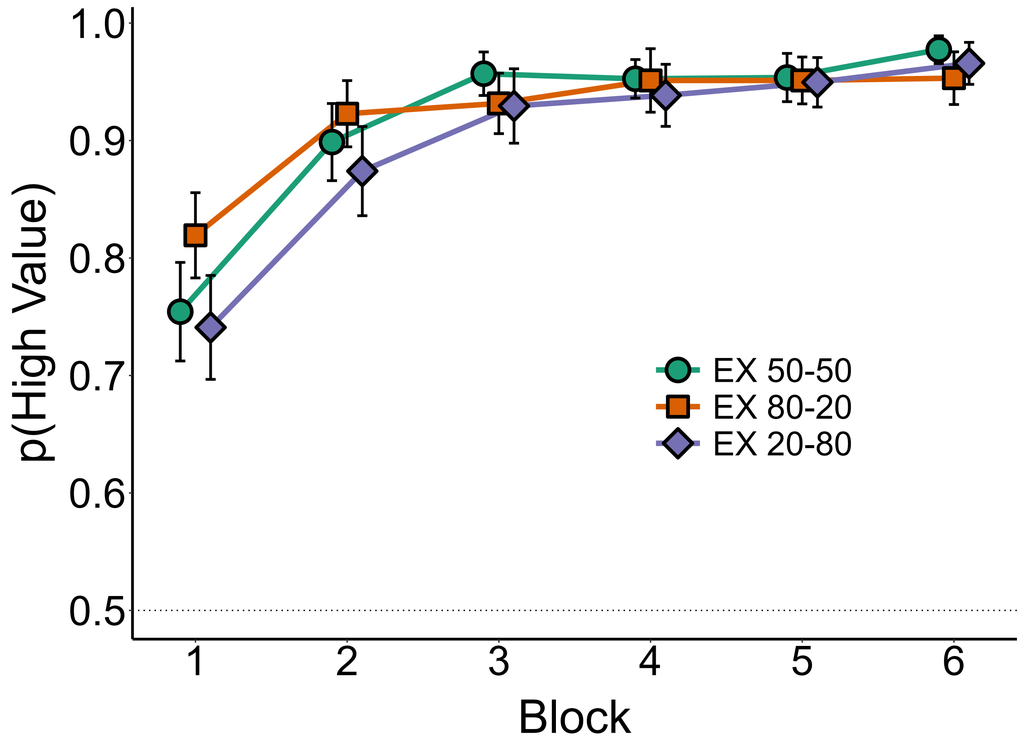

## Risk Preference Trials

**Plot - Block means with 95% CIs**

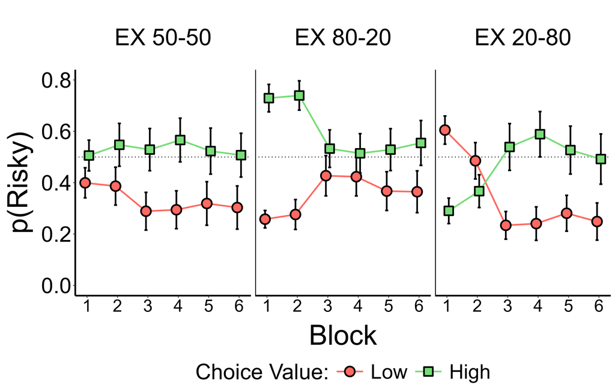

**Plot - Extreme-Outcome Scores with 95% CIs (Blocks 5 & 6)**

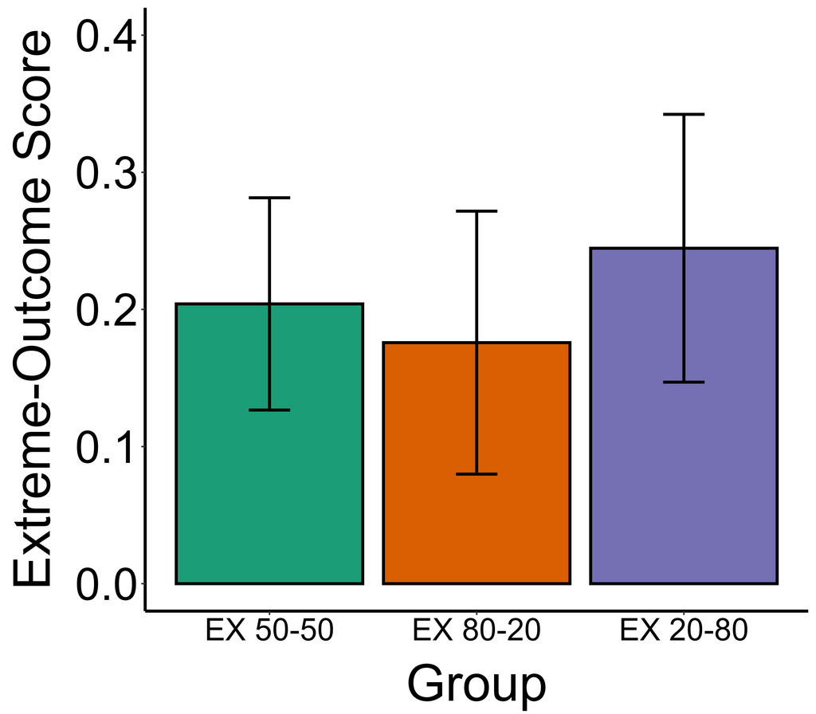

**Plot - Interaction plot with 95% CIs (Blocks 5 & 6)**

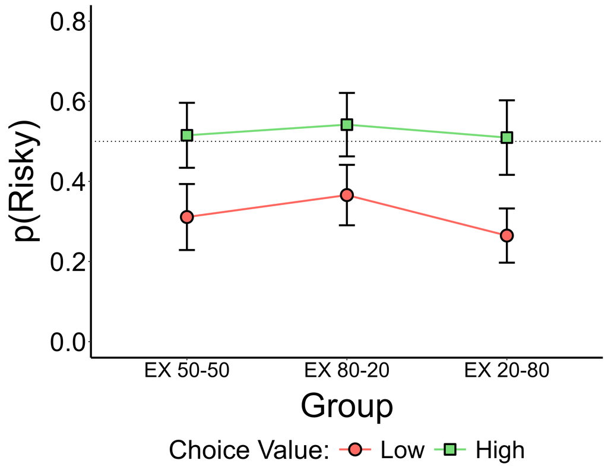

**Summary Stats for Extreme-Outcome Scores**

| group | n | m | df | alpha | t_crit | se | moe | ci_bot | ci_top | mu | d |
| --- | --- | --- | --- | --- | --- | --- | --- | --- | --- | --- | --- |
| EX 50-50 | 58 | 0.2040 | 57 | 0.05 | 2.0025 | 0.0387 | 0.0774 | 0.1266 | 0.2814 | 0 | 0.6930 |
| EX 80-20 | 64 | 0.1758 | 63 | 0.05 | 1.9983 | 0.0480 | 0.0959 | 0.0799 | 0.2717 | 0 | 0.4579 |
| EX 20-80 | 62 | 0.2446 | 61 | 0.05 | 1.9996 | 0.0488 | 0.0976 | 0.1470 | 0.3423 | 0 | 0.6362 |

**Main Effects**

#### ANOVA Table

|  | Model | df | AIC | BIC | logLik | Test | L.Ratio | p.value | BF_10 |
| --- | --- | --- | --- | --- | --- | --- | --- | --- | --- |
| base_mod | 1 | 4 | 226.496 | 242.128 | -109.248 |  | NA | NA | NA |
| grp_mod | 2 | 6 | 228.323 | 251.772 | -108.162 | 1 vs 2 | 2.172 | 0.338 | 8.000000e-03 |
| value_mod | 3 | 7 | 176.484 | 203.840 | -81.242 | 2 vs 3 | 53.840 | 0.000 | 2.559852e+10 |
| grp_val | 4 | 9 | 179.296 | 214.469 | -80.648 | 3 vs 4 | 1.188 | 0.552 | 5.000000e-03 |

**Main Effect of Group:**

$\chi^2(2) = 2.17, p = 0.338, BF_{10} < .01$

**Main Effect of Choice Value (i.e., Extreme Outcome effect):**

$\chi^2(1) = 53.84, p < .001, BF_{10} > 150$

**Interaction: Group $\times$ Choice Value:**

$\chi^2(2) = 1.19, p = 0.552, BF_{10} < .01$

**Planned Comparisons**

#### ANOVA Table

|  | Value | Std.Error | DF | t-value | p-value | sig | r_effect |
| --- | --- | --- | --- | --- | --- | --- | --- |
| (Intercept) | 0.413 | 0.034 | 181 | 12.219 | 0.000 | TRUE | 0.672 |
| group 8020_vs_50 | 0.041 | 0.047 | 181 | 0.872 | 0.384 | FALSE | 0.065 |
| group 2080_vs_50 | -0.026 | 0.047 | 181 | -0.552 | 0.581 | FALSE | 0.041 |
| choice_value1 | 0.102 | 0.024 | 181 | 4.336 | 0.000 | TRUE | 0.307 |
| group 8020_vs_50 :choice_value1 | -0.014 | 0.032 | 181 | -0.435 | 0.664 | FALSE | 0.032 |
| group 2080_vs_50 :choice_value1 | 0.020 | 0.033 | 181 | 0.620 | 0.536 | FALSE | 0.046 |

**EX 80-20 vs. EX 50-50:**

$b = 0.041, t(181) = 0.872, p = 0.384, r = 0.065$

**EX 20-80 vs. EX 50-50:**

$b = -0.026, t(181) = -0.552, p = 0.581, r = 0.041$

**EX 80-20 vs. EX 50-50 | Choice Value (High vs. Low):**

$b = -0.014, t(181) = -0.435, p = 0.664, r = 0.032$

**EX 20-80 vs. EX 50-50 | Choice Value (High vs. Low):**

$b = 0.02, t(181) = 0.62, p = 0.536, r = 0.046$

**Notes**

- All plots and analyses are showing the combined effect of block 5 and 6.
- Bayes Factors are reported as Inverse Bayes Factors, this means larger values indicate greater support for the effect. Anything less than 1 should be considered as contributing no evidence.

## First-Outcome Judgement

**Plot - Proportions**

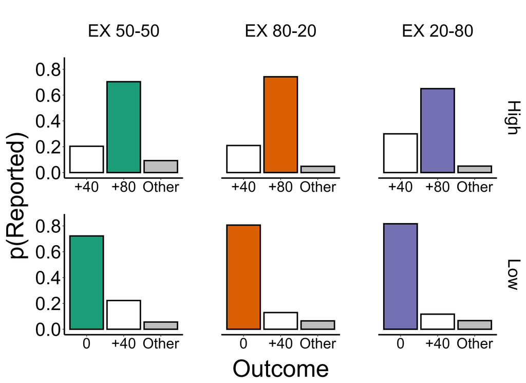

Note:

- Proportions are taken within group and context (High/Low). E.g., All three bars in the top left facet sum to 1, all three bars in the top middle facet sum to 1, and so on.
- Since non-numeric responses were permissible by the experiment’s program, data was filtered to remove all non-numeric inputs. If a participant’s inputs had a cumulative sum less than 20 or greater than 300, their results were removed. In total, 8 participants met this criteria.

**Goodness-of-fit tests - Extreme vs Non-Extreme Reporting**

#### High Value Result

$\chi^2(1) = 40.752, p < 0.001, w = 0.5$

#### Low Value Result

$\chi^2(1) = 71.112, p < 0.001, w = 0.66$

**2 $\times$ 3 Chi-Squared Tests - Extreme vs Non-Extreme $\times$ Group**

#### High Value Results

High Value Contingency Table

|  | No | Yes |
| --- | --- | --- |
| EX 50-50 | 11 | 38 |
| EX 80-20 | 13 | 44 |
| EX 20-80 | 16 | 39 |

$\chi^2(2) = 0.81, p = 0.667, \varphi_c = 0.07$

- Cannot rule out that recalling the extreme value is independent of group.

Standardized Residuals

|  | No | Yes |
| --- | --- | --- |
| EX 50-50 | -0.465 | 0.465 |
| EX 80-20 | -0.443 | 0.443 |
| EX 20-80 | 0.898 | -0.898 |

p-values

|  | No | Yes |
| --- | --- | --- |
| EX 50-50 | 0.642 | 0.642 |
| EX 80-20 | 0.658 | 0.658 |
| EX 20-80 | 0.369 | 0.369 |

None of the three conditions differ significantly from the expected value.

#### Low Value Results

Low Value Contingency Table

|  | No | Yes |
| --- | --- | --- |
| EX 50-50 | 12 | 37 |
| EX 80-20 | 8 | 49 |
| EX 20-80 | 7 | 48 |

$\chi^2(2) = 3.04, p = 0.219, \varphi_c = 0.14$

- Cannot rule out that recalling the extreme value is independent of group.

Standardized Residuals

|  | No | Yes |
| --- | --- | --- |
| EX 50-50 | 1.734 | -1.734 |
| EX 80-20 | -0.688 | 0.688 |
| EX 20-80 | -0.989 | 0.989 |

p-values

|  | No | Yes |
| --- | --- | --- |
| EX 50-50 | 0.083 | 0.083 |
| EX 80-20 | 0.492 | 0.492 |
| EX 20-80 | 0.323 | 0.323 |

- None of the three conditions differ significantly from the expected value.

#### Post-Hoc Pairwise Fisher-Exact Tests

| value | comparison | odds_ratio | p_value | CI_low | CI_upper | p_value_adj |
| --- | --- | --- | --- | --- | --- | --- |
| High | EX 50-50 : EX 80-20 | 0.9799 | 1.0000 | 0.3521 | 2.6883 | 1.0000 |
| High | EX 50-50 : EX 20-80 | 0.7080 | 0.5056 | 0.2603 | 1.8687 | 1.0000 |
| High | EX 80-20 : EX 20-80 | 0.7223 | 0.5201 | 0.2805 | 1.8310 | 1.0000 |
| Low | EX 50-50 : EX 80-20 | 1.9735 | 0.2157 | 0.6633 | 6.1822 | 1.0000 |
| Low | EX 50-50 : EX 20-80 | 2.2068 | 0.1357 | 0.7174 | 7.3155 | 0.8141 |
| Low | EX 80-20 : EX 20-80 | 1.1184 | 1.0000 | 0.3256 | 3.9337 | 1.0000 |

- Nothing reached significance.

Note:

- In the contingency tables, ‘Yes’ indicates the extreme value was recalled, ‘No’ indicates that it was not.
- Only recalled outcomes that matched the programmed values were included. i.e., if they saw the *High Value Risky Door*, 80 was logged as “Yes” and 40 was logged as “No.” If they saw the *Low Value Risky Door*, 0 was logged as “Yes”, 40 was logged as “No”. Participants who responded with any “other” values were removed from the analysis. Only Risky doors were evaluated.
- In total, removing “other” responses resulted 15 participants being excluded from these analyses leaving a final N = 161.
- $w$ is Cohen’s w
- $\varphi_c$ is Cramér’s V, a measure of association for two nominal variables (i.e., an effect size of sorts). It can take a value between 0 and 1, with 0 indicating no association (i.e., full independence).
- A post-hoc analysis on each $\chi^2$ test was conducted by evaluating the standardized residuals from the chi-square analysis because it seemed the most natural approach. However, pairwise Fisher Exact tests across the three conditions were also run and is what was reported in the manuscript. The `p_value_adj` column shows corrected p-values using the Holm-Bonferroni method.

## Frequency Judgement

**Plot - Means and 95% CIs**

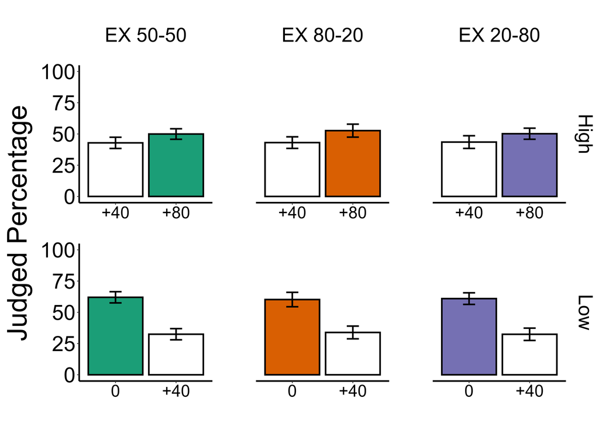

**2x3 ANOVA using linear mixed-effects models fit by maximum likelihood**

#### Main Effects

|  | Model | df | AIC | BIC | logLik | Test | L.Ratio | p.value | BF_10 |
| --- | --- | --- | --- | --- | --- | --- | --- | --- | --- |
| base | 1 | 4 | 3240.858 | 3256.490 | -1616.429 |  | NA | NA | NA |
| cond_mod | 2 | 6 | 3244.737 | 3268.185 | -1616.368 | 1 vs 2 | 0.121 | 0.941 | 0.003 |
| HL_mod | 3 | 7 | 3221.010 | 3248.366 | -1603.505 | 2 vs 3 | 25.727 | 0.000 | 20117.182 |
| int_mod | 4 | 9 | 3224.021 | 3259.194 | -1603.010 | 3 vs 4 | 0.989 | 0.610 | 0.004 |

**Main Effect of Group:**

$\chi^2(2) = 0.121$, $p = 0.941$, $BF_{10} < .01$

**Main Effect of Value (High vs. Low):**

$\chi^2(1) = 25.727$, $p < 0.001$, $BF_{10} > 150$

**Interaction:**

$\chi^2(2) = 0.989$, $p = 0.61$, $BF_{10} < .01$

#### Planned Contrasts

|  | Value | Std.Error | DF | t-value | p-value | r_effect |
| --- | --- | --- | --- | --- | --- | --- |
| (Intercept) | 55.991 | 1.819 | 181 | 30.778 | 0.000 | 0.916 |
| group 8020_vs_50 | 0.454 | 2.512 | 181 | 0.181 | 0.857 | 0.013 |
| group 2080_vs_50 | -0.403 | 2.531 | 181 | -0.159 | 0.874 | 0.012 |
| fj_value1 | -6.026 | 1.714 | 181 | -3.517 | 0.001 | 0.253 |
| group 8020_vs_50 :fj_value1 | 2.252 | 2.366 | 181 | 0.952 | 0.342 | 0.071 |
| group 2080_vs_50 :fj_value1 | 0.647 | 2.384 | 181 | 0.271 | 0.786 | 0.020 |

**EX 80-20 vs. EX 50-50:**

$b = 0.454$, $t(181) = 0.181$, $p = 0.857$, $r = 0.013$

**EX 20-80 vs. EX 50-50:**

$b = -0.403$, $t(181) = -0.159$, $p = 0.874$, $r = 0.012$

**EX 80-20 vs. EX 50-50 | Value (High vs. Low):**

$b = 2.252$, $t(181) = 0.952$, $p = 0.342$, $r = 0.071$

**EX 20-80 vs. EX 50-50 | Value (High vs. Low):**

$b = 0.647$, $t(181) = 0.271$, $p = 0.786$, $r = 0.02$

**Notes**

- ANOVA was conducted only on judgements for the risky extreme values (0 and +80).
- Bayes Factors are reported as Inverse Bayes Factors, this means larger values indicate greater support for the effect. Anything less than 1 should be considered as contributing no evidence.

# **Experiment 1b**

**Contingencies**

##### Low Value Options

- Fixed: 20 (Door 3)
- Risky: 0 or 40 (Door 4)

##### High Value Options

- Fixed: 60 (Door 1)
- Risky: 40 or 80 (Door 2)

##### Trials

- Six blocks of 80 trials.
- Decision Trials: (fixed low vs risky low) & (fixed high vs risky high) - 24 per block (12 low, 12 high)
- Single door trials: one door to click - 40 per block
- Catch trials: high vs low - 16 per block

##### BEST 80-20

- Block 1: 80% chance of best outcome on risky options.
- Block 2: 50% of best outcome on risky options.
- Block 3: 20% chance of best outcome on risky options.
- Block 4-6: 50% of best outcome on risky options.

##### BEST 20-80

- Block 1: 20% chance of best outcome on risky options.
- Block 2: 50% of best outcome on risky options.
- Block 3: 80% chance of best outcome on risky options.
- Block 4-6: 50% of best outcome on risky options.

##### BEST 50-50 (control)

- All blocks: 50% of best outcome on risky options.

## Participant Information

**Pre-catch exclusion**

N = 190

| group | gender | n | age_mean | age_sd | age_median | age_IQR |
| --- | --- | --- | --- | --- | --- | --- |
| BEST 50-50 | F | 50 | 19.220 | 3.699 | 18.5 | 1 |
| BEST 50-50 | M | 16 | 19.375 | 1.544 | 19.0 | 2 |
| BEST 80-20 | F | 48 | 19.500 | 3.156 | 18.0 | 1 |
| BEST 80-20 | M | 13 | 19.231 | 1.787 | 19.0 | 1 |
| BEST 20-80 | F | 38 | 18.842 | 1.636 | 18.0 | 1 |
| BEST 20-80 | M | 25 | 19.840 | 1.748 | 19.0 | 2 |

**Post-catch exclusion**

N = 183

| group | gender | n | age_mean | age_sd | age_median | age_IQR |
| --- | --- | --- | --- | --- | --- | --- |
| BEST 50-50 | F | 46 | 19.326 | 3.842 | 19 | 1 |
| BEST 50-50 | M | 15 | 19.467 | 1.552 | 19 | 2 |
| BEST 80-20 | F | 48 | 19.500 | 3.156 | 18 | 1 |
| BEST 80-20 | M | 13 | 19.231 | 1.787 | 19 | 1 |
| BEST 20-80 | F | 36 | 18.889 | 1.670 | 18 | 1 |
| BEST 20-80 | M | 25 | 19.840 | 1.748 | 19 | 2 |

#### Condition totals:

| group | n | age_mean | age_sd | age_median | age_IQR |
| --- | --- | --- | --- | --- | --- |
| BEST 50-50 | 61 | 19.361 | 3.411 | 19 | 1 |
| BEST 80-20 | 61 | 19.443 | 2.907 | 18 | 1 |
| BEST 20-80 | 61 | 19.279 | 1.752 | 19 | 2 |

- Total number of catch trial exclusions = 7.
- Catch trial exclusions were based on block 5 and 6 performance.

## Catch Trials

**Plot - Block means with 95% CIs**

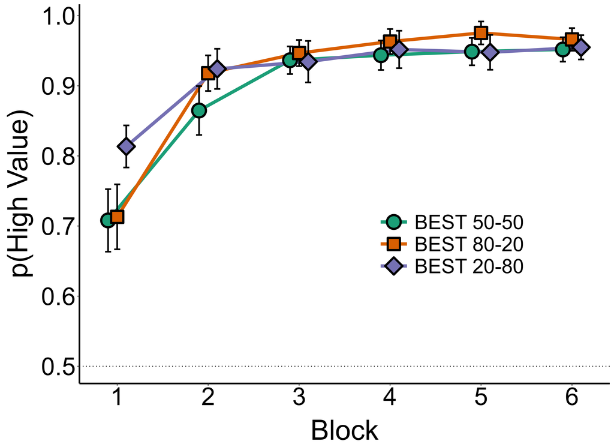

## Risk Preference Trials

**Plot - Block means with 95% CIs**

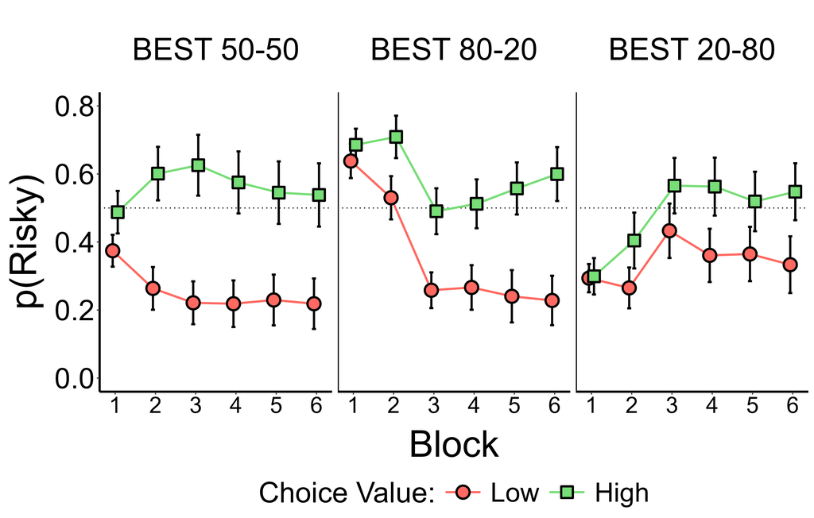

**Plot - Extreme-Outcome Scores with 95% CIs (Blocks 5 & 6)**

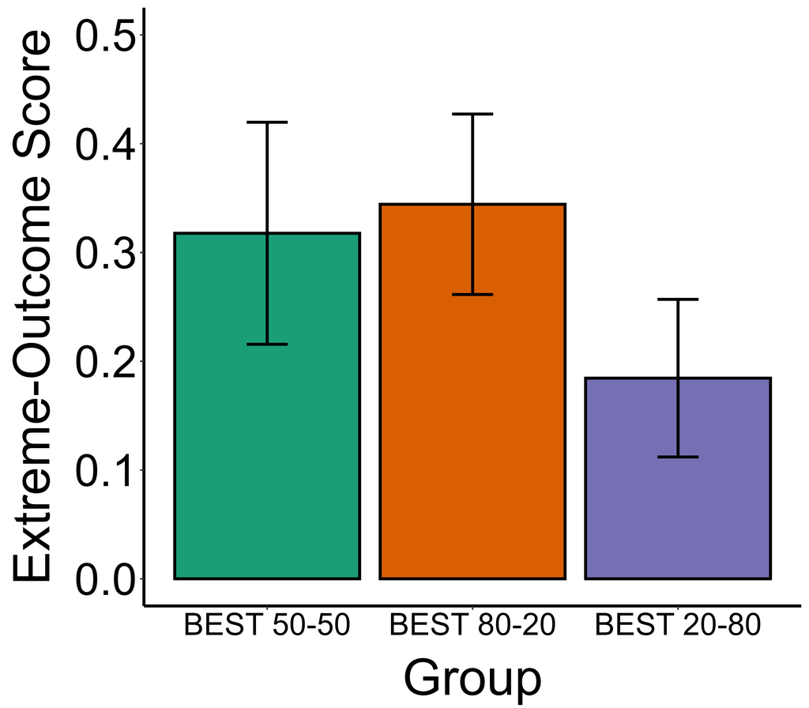

**Plot - Interaction plot with 95% CIs (Block 5 & 6)**

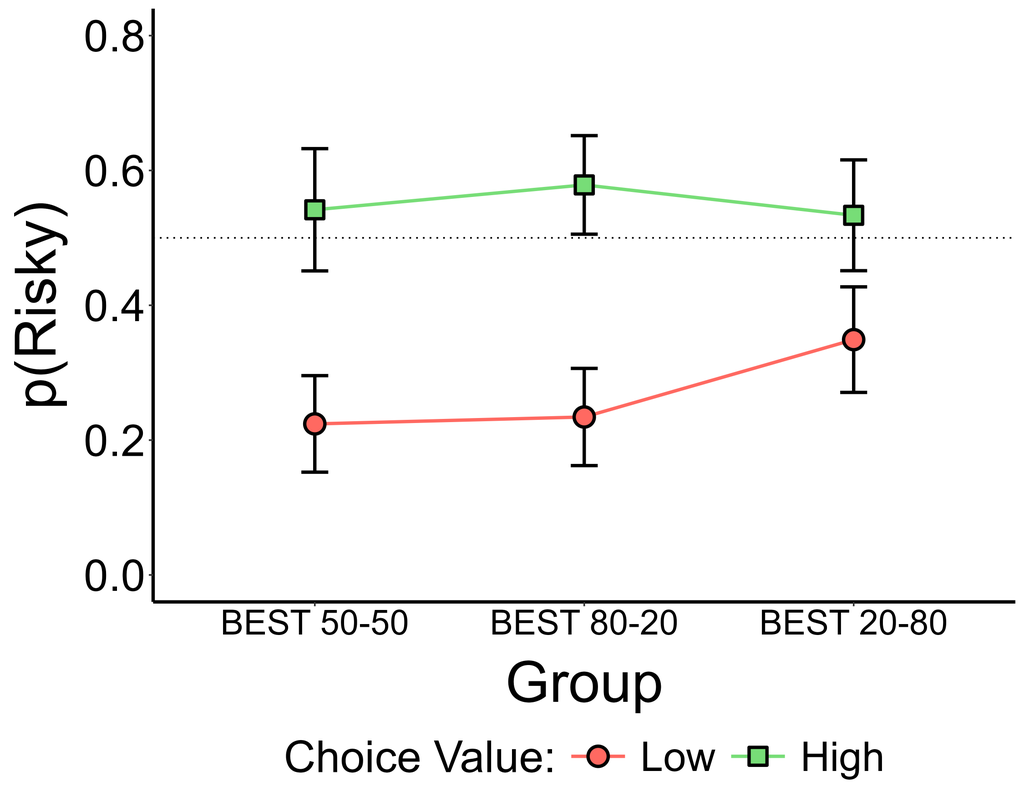

**Summary Stats for Extreme-Outcome Scores**

| group | n | m | df | alpha | t_crit | se | moe | ci_bot | ci_top | mu | d |
| --- | --- | --- | --- | --- | --- | --- | --- | --- | --- | --- | --- |
| BEST 50-50 | 61 | 0.3176 | 60 | 0.05 | 2.0003 | 0.0510 | 0.1021 | 0.2156 | 0.4197 | 0 | 0.7970 |
| BEST 80-20 | 61 | 0.3443 | 60 | 0.05 | 2.0003 | 0.0415 | 0.0830 | 0.2613 | 0.4272 | 0 | 1.0629 |
| BEST 20-80 | 61 | 0.1844 | 60 | 0.05 | 2.0003 | 0.0362 | 0.0724 | 0.1120 | 0.2569 | 0 | 0.6520 |

**Main Effects**

#### ANOVA Table

|  | Model | df | AIC | BIC | logLik | Test | L.Ratio | p.value | BF_10 |
| --- | --- | --- | --- | --- | --- | --- | --- | --- | --- |
| base_mod | 1 | 4 | 247.353 | 262.964 | -119.677 |  | NA | NA | NA |
| grp_mod | 2 | 6 | 249.708 | 273.124 | -118.854 | 1 vs 2 | 1.645 | 0.439 | 6.000000e-03 |
| value_mod | 3 | 7 | 157.116 | 184.435 | -71.558 | 2 vs 3 | 94.592 | 0.000 | 1.813658e+19 |
| grp_val | 4 | 9 | 153.345 | 188.469 | -67.673 | 3 vs 4 | 7.771 | 0.021 | 1.330000e-01 |

**Main Effect of Group:**

$\chi^2(2) = 1.65, p = 0.439, BF_{10} < .01$

**Main Effect of Choice Value (i.e., Extreme Outcome effect):**

$\chi^2(1) = 94.59, p < .001, BF_{10} > 150$

**Interaction: Group $\times$ Choice Value:**

$\chi^2(2) = 7.77, p = 0.021, BF_{10} = 0.133$

- Note: while the p-value is technically significant, the Bayes Factor implies the interaction contributes nothing worthwhile.

**Planned Comparisons**

#### ANOVA Table

|  | Value | Std.Error | DF | t-value | p-value | sig | r_effect |
| --- | --- | --- | --- | --- | --- | --- | --- |
| (Intercept) | 0.383 | 0.033 | 180 | 11.747 | 0.000 | TRUE | 0.659 |
| group 8020_vs_50 | 0.024 | 0.046 | 180 | 0.511 | 0.610 | FALSE | 0.038 |
| group 2080_vs_50 | 0.058 | 0.046 | 180 | 1.267 | 0.207 | FALSE | 0.094 |
| choice_value1 | 0.159 | 0.022 | 180 | 7.329 | 0.000 | TRUE | 0.479 |
| group 8020_vs_50 :choice_value1 | 0.013 | 0.031 | 180 | 0.435 | 0.664 | FALSE | 0.032 |
| group 2080_vs_50 :choice_value1 | -0.067 | 0.031 | 180 | -2.173 | 0.031 | TRUE | 0.160 |

**BEST 80-20 vs. BEST 50-50:**

$b = 0.024, t(180) = 0.511, p = 0.61, r = 0.038$

**BEST 20-80 vs. BEST 50-50:**

$b = 0.058, t(180) = 1.267, p = 0.207, r = 0.094$

**BEST 80-20 vs. BEST 50-50 | Choice Value (High vs. Low):**

$b = 0.013, t(180) = 0.435, p = 0.664, r = 0.032$

**BEST 20-80 vs. BEST 50-50 | Choice Value (High vs. Low):**

$b = -0.067, t(180) = -2.173, p = 0.031, r = 0.16$

**Notes**

- All plots and analyses are showing the combined effect of block 5 and 6.
- Bayes Factors are reported as Inverse Bayes Factors, this means larger values indicate greater support for the effect. Anything less than 1 should be considered as contributing no evidence.

## First-Outcome Judgement

**Plot - Proportions**

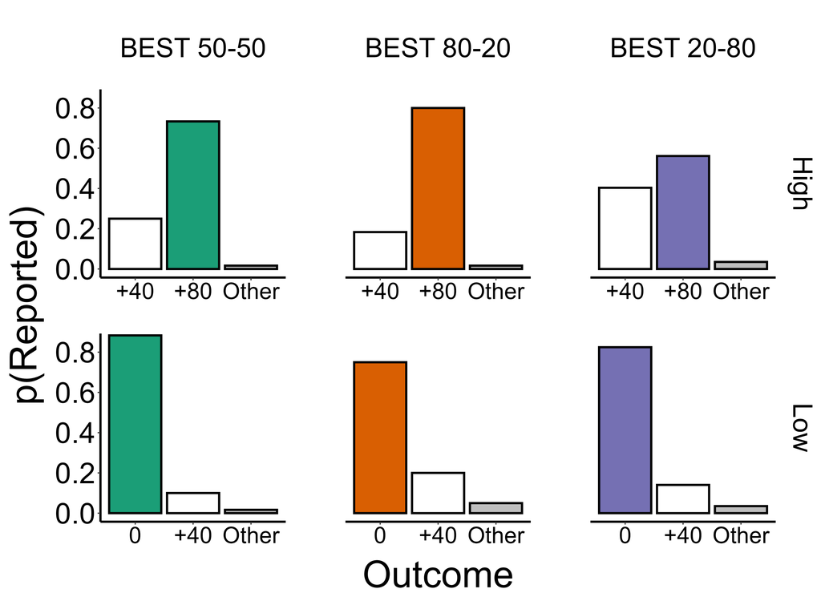

Note:

- Proportions are taken within group and context (High/Low). E.g., All three bars in the top left facet sum to 1, all three bars in the top middle facet sum to 1, and so on.
- Since non-numeric responses were permissible by the experiment’s program, data was filtered to remove all non-numeric inputs. If a participant’s inputs had a cumulative sum less than 20 or greater than 300, their results were removed. In total, 6 participants met this criteria.

**Goodness-of-fit tests - Extreme vs Non-Extreme Reporting**

#### High Value Result

$\chi^2(1) = 30.857, p < 0.001, w = 0.43$

#### Low Value Result

$\chi^2(1) = 85.714, p < 0.001, w = 0.71$

**2 $\times$ 3 Chi-Squared Tests - Extreme vs Non-Extreme $\times$ Group**

#### High Value Results

High Value Contingency Table

|  | No | Yes |
| --- | --- | --- |
| BEST 50-50 | 15 | 43 |
| BEST 80-20 | 10 | 47 |
| BEST 20-80 | 23 | 30 |

$\chi^2(2) = 9.31, p = 0.01, \varphi_c = 0.24$

- Recalling the extreme value is dependent on condition.

Standardized Residuals

|  | No | Yes |
| --- | --- | --- |
| BEST 50-50 | -0.56 | 0.56 |
| BEST 80-20 | -2.27 | 2.27 |
| BEST 20-80 | 2.89 | -2.89 |

p-values

|  | No | Yes |
| --- | --- | --- |
| BEST 50-50 | 0.572 | 0.572 |
| BEST 80-20 | 0.023 | 0.023 |
| BEST 20-80 | 0.004 | 0.004 |

The *BEST 80-20* and *BEST 20-80* conditions both differ significantly from the expected value. The *BEST 80-20* condition tends to recall the extreme value, whereas *BEST 20-80* does not.

- BEST 80-20: $z = 2.27, p = 0.023$
- BEST 20-80: $z = -2.89, p = 0.004$

#### Low Value Results

Low Value Contingency Table

|  | No | Yes |
| --- | --- | --- |
| BEST 50-50 | 5 | 53 |
| BEST 80-20 | 12 | 45 |
| BEST 20-80 | 7 | 46 |

$\chi^2(2) = 3.7, p = 0.157, \varphi_c = 0.15$

- Cannot rule out that recalling the extreme value is independent of group.

Standardized Residuals

|  | No | Yes |
| --- | --- | --- |
| BEST 50-50 | -1.524 | 1.524 |
| BEST 80-20 | 1.796 | -1.796 |
| BEST 20-80 | -0.271 | 0.271 |

p-values

|  | No | Yes |
| --- | --- | --- |
| BEST 50-50 | 0.128 | 0.128 |
| BEST 80-20 | 0.072 | 0.072 |
| BEST 20-80 | 0.786 | 0.786 |

- None of the three conditions differ significantly from the expected value.

#### Post-Hoc Pairwise Fisher-Exact Tests

| value | comparison | odds_ratio | p_value | CI_low | CI_upper | p_value_adj |
| --- | --- | --- | --- | --- | --- | --- |
| High | BEST 50-50 : BEST 80-20 | 1.6325 | 0.3667 | 0.6105 | 4.5340 | 0.9612 |
| High | BEST 50-50 : BEST 20-80 | 0.4583 | 0.0713 | 0.1883 | 1.0884 | 0.3526 |
| High | BEST 80-20 : BEST 20-80 | 0.2809 | 0.0037 | 0.1037 | 0.7154 | 0.0223 |
| Low | BEST 50-50 : BEST 80-20 | 0.3569 | 0.0705 | 0.0914 | 1.1908 | 0.3526 |
| Low | BEST 50-50 : BEST 20-80 | 0.6226 | 0.5456 | 0.1453 | 2.4571 | 0.9612 |
| Low | BEST 80-20 : BEST 20-80 | 1.7435 | 0.3204 | 0.5713 | 5.7317 | 0.9612 |

- Recalling the extreme value was found to be dependent on condition ($p = 0.022$) only when high value options in the BEST 80-20 and BEST 20-80 conditions are considered (Row 3 in the table). Everything else fails to reach significance.

## Frequency Judgement

**Plot - Means and 95% CIs**

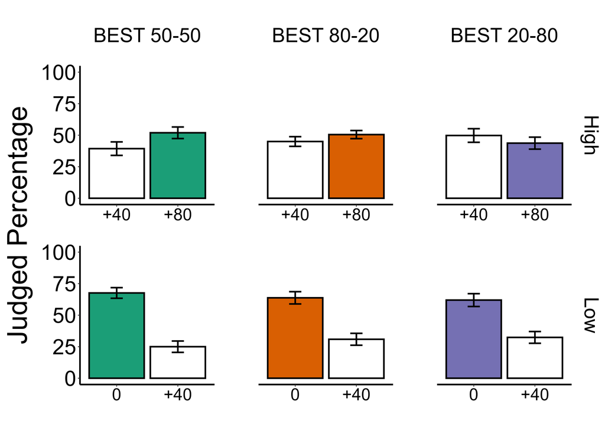

**2x3 ANOVA using linear mixed-effects models fit by maximum likelihood**

#### Main Effects

|  | Model | df | AIC | BIC | logLik | Test | L.Ratio | p.value | BF_10 |
| --- | --- | --- | --- | --- | --- | --- | --- | --- | --- |
| base | 1 | 4 | 3215.285 | 3230.896 | -1603.643 |  | NA | NA | NA |
| cond_mod | 2 | 6 | 3211.195 | 3234.611 | -1599.598 | 1 vs 2 | 8.090 | 0.018 | 1.560000e-01 |
| HL_mod | 3 | 7 | 3145.344 | 3172.662 | -1565.672 | 2 vs 3 | 67.851 | 0.000 | 2.831444e+13 |
| int_mod | 4 | 9 | 3148.096 | 3183.220 | -1565.048 | 3 vs 4 | 1.248 | 0.536 | 5.000000e-03 |

**Main Effect of Condition:**

$\chi^2(2) = 8.09$, $p = 0.018$, $BF_{10} = 0.156$

**Main Effect of Value (High vs. Low):**

$\chi^2(1) = 67.851$, $p < 0.001$, $BF_{10} > 150$

**Interaction:**

$\chi^2(2) = 1.248$, $p = 0.536$, $BF_{10} < .01$

#### Planned Contrasts

|  | Value | Std.Error | DF | t-value | p-value | r_effect |
| --- | --- | --- | --- | --- | --- | --- |
| (Intercept) | 59.779 | 1.589 | 180 | 37.609 | 0.000 | 0.942 |
| group 8020_vs_50 | -2.648 | 2.248 | 180 | -1.178 | 0.240 | 0.087 |
| group 2080_vs_50 | -6.943 | 2.248 | 180 | -3.089 | 0.002 | 0.224 |
| fj_value1 | -7.844 | 1.589 | 180 | -4.935 | 0.000 | 0.345 |
| group 8020_vs_50 :fj_value1 | 1.205 | 2.248 | 180 | 0.536 | 0.593 | 0.040 |
| group 2080_vs_50 :fj_value1 | -1.287 | 2.248 | 180 | -0.572 | 0.568 | 0.043 |

**BEST 80-20 vs. BEST 50-50:**

$b = -2.648$, $t(180) = -1.178$, $p = 0.24$, $r = 0.087$

**BEST 20-80 vs. BEST 50-50:**

$b = -6.943$, $t(180) = -3.089$, $p = 0.002$, $r = 0.224$

**BEST 80-20 vs. BEST 50-50 | Value (High vs. Low):**

$b = 1.205$, $t(180) = 0.536$, $p = 0.593$, $r = 0.04$

**BEST 20-80 vs. BEST 50-50 | Value (High vs. Low):**

$b = -1.287$, $t(180) = -0.572$, $p = 0.568$, $r = 0.043$

**Notes**

- ANOVA was conducted only on judgements for the risky extreme values (0 and +80).
- Bayes Factors are reported as Inverse Bayes Factors, this means larger values indicate greater support for the effect. Anything less than 1 should be considered as contributing no evidence.

# **R Citations**

R version 4.5.1 (2025-06-13 ucrt)

- ggh4x (0.3.1) (van den Brand, 2024)
- Hmisc (5.2.3) (Harrell Jr, 2024)
- nlme (3.1.168) (Pinheiro et al., 2023)
- RColorBrewer (1.1.3) (Neuwirth, 2022)
- rcompanion (2.5.0) (Mangiafico, 2024)
- tidyverse (2.0.0) (Wickham et al., 2019)

# **References**

Harrell Jr, F. E. (2024). *Hmisc: Harrell miscellaneous*. https://CRAN.R-project.org/package=Hmisc

Mangiafico, S. S. (2024). *rcompanion: Functions to support extension education program evaluation*. Rutgers Cooperative Extension. https://CRAN.R-project.org/package=rcompanion/

Neuwirth, E. (2022). *RColorBrewer: ColorBrewer palettes*. https://CRAN.R-project.org/package=RColorBrewer

Pinheiro, J., Bates, D., & R Core Team. (2023). *Nlme: Linear and nonlinear mixed effects models*. https://CRAN.R-project.org/package=nlme

R Core Team. (2024). *R: A language and environment for statistical computing*. R Foundation for Statistical Computing. https://www.R-project.org/

van den Brand, T. (2024). *ggh4x: Hacks for ’ggplot2’*. https://CRAN.R-project.org/package=ggh4x

Wickham, H., Averick, M., Bryan, J., Chang, W., McGowan, L. D., François, R., Grolemund, G., Hayes, A., Henry, L., Hester, J., Kuhn, M., Pedersen, T. L., Miller, E., Bache, S. M., Müller, K., Ooms, J., Robinson, D., Seidel, D. P., Spinu, V., … Yutani, H. (2019). Welcome to the tidyverse. *Journal of Open Source Software*, *4*(43), 1686. https://doi.org/10.21105/joss.01686